# Homework 04: Visualization, Correlation, and Linear Models

- 10 pt: Overall quality of spelling, grammar, puctuation, etc. of written sentences.
- 10 pt: Code is written in [PEP 8](https://www.python.org/dev/peps/pep-0008/) style.
- 80 pt: Homework questions.

```python
MY_UNIQNAME = 'kaikang'
```

## Download the data from:

- https://www.kaggle.com/datasnaek/youtube-new

> YouTube provides a list of trending videos on it's site, determined by user interaction metrics such as likes, comments, and views. This dataset includes months of daily trending video across five different regions: the United States ("US"), Canada ("CA"), Great Britain ("GB"), Germany ("DE"), and France ("FR").
- https://www.kaggle.com/abcsds/pokemon

> This data set includes 721 Pokemon, including their number, name, first and second type, and basic stats: HP, Attack, Defense, Special Attack, Special Defense, and Speed.

## Part 1: Answer the questions below based on the *[YouTube dataset](https://www.kaggle.com/datasnaek/youtube-new)*

- Write Python code that can answer the following questions, and
- **Explain your answers in plain English.**

### Q1. For 15 Points: Compare the distributions of comments, views, likes, and dislikes

- Plot histograms for these metrics *for the US*. What can you say about them?
- Try to apply a log transformation, and plot the histograms again. How do they look now?
- Create a pairplot *for the US*, as we did in this week's lab. Do you see anything interesting?
- Create additional pairplots for the other four regions. Do they look similar?

```python
# put your code here
import pandas as pd
import numpy as np
import seaborn as sns
import matplotlib.pyplot as plt
'''
ca = pd.read_csv('CAvideos.csv')
lst = []
for i in range(ca.size):
    lst.append('CA')
ca['region'] = pd.Series(lst)'''

us = pd.read_csv('USvideos.csv')
us
ca = pd.read_csv('CAvideos.csv')
gb = pd.read_csv('GBvideos.csv')
de = pd.read_csv('DEvideos.csv')
fr = pd.read_csv('FRvideos.csv')
```

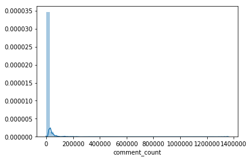

```python
sns.distplot(us['comment_count'])
```

```python
us['comment_count'].min()
```

```
0
```

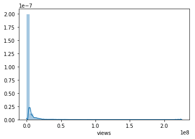

```python
sns.distplot(us['views'])
```

```python
us['views'].min()
```

```
549
```

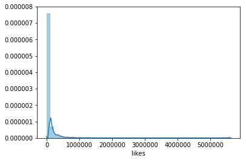

```python
sns.distplot(us['likes'])
```

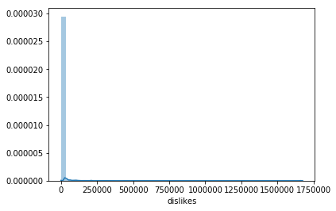

```python
sns.distplot(us['dislikes'])
```

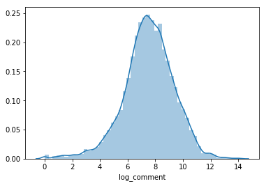

```python
log_comment = pd.Series(us['comment_count'][us['comment_count'] != 0]. \
    apply(np.log), name = 'log_comment')
sns.distplot(log_comment)
```

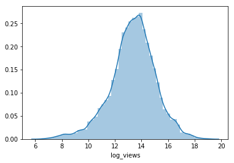

```python
log_views = pd.Series(us['views'].apply(np.log), name = 'log_views')
sns.distplot(log_views)
```

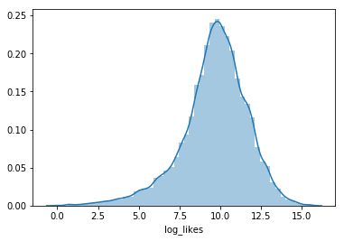

```python
log_likes = pd.Series(us['likes'][us['likes']!= 0].\
    apply(np.log), name = 'log_likes')
sns.distplot(log_likes)
```

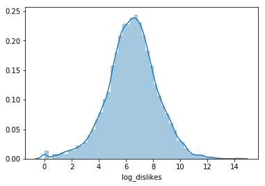

```python
log_dislikes = pd.Series(us['dislikes'][us['dislikes']!= 0].\
    apply(np.log), name = 'log_dislikes')
sns.distplot(log_dislikes)
```

```python
#sns.pairplot(us)
us_num = us[['views','likes','dislikes','comment_count']].copy()
us_num.head()
```

|  | views | likes | dislikes | comment_count |
| --- | --- | --- | --- | --- |
| 0 | 748374 | 57527 | 2966 | 15954 |
| 1 | 2418783 | 97185 | 6146 | 12703 |
| 2 | 3191434 | 146033 | 5339 | 8181 |
| 3 | 343168 | 10172 | 666 | 2146 |
| 4 | 2095731 | 132235 | 1989 | 17518 |

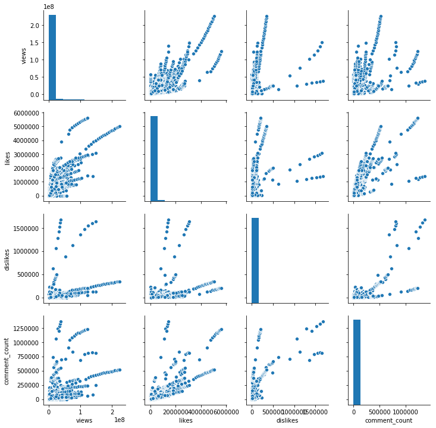

```python
sns.pairplot(us_num)
```

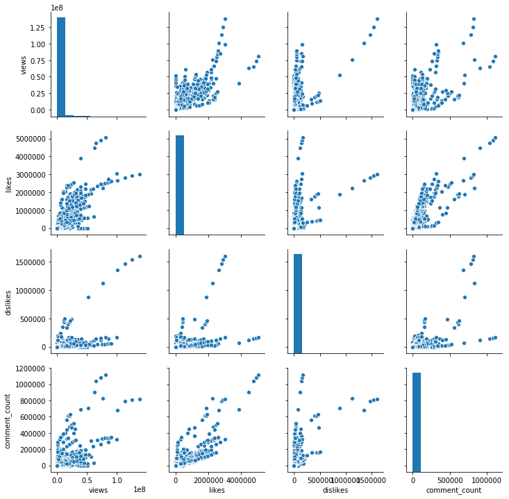

```python
ca_num = ca[['views','likes','dislikes','comment_count']].copy()
sns.pairplot(ca_num)
```

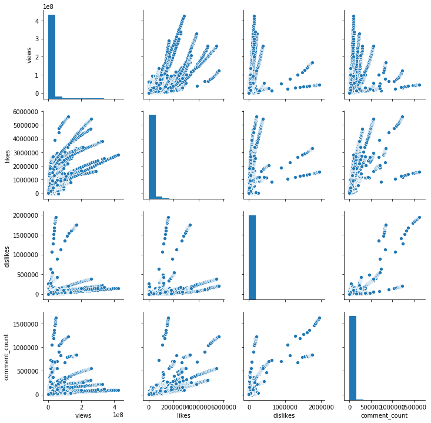

```python
gb_num = gb[['views','likes','dislikes','comment_count']].copy()
sns.pairplot(gb_num)
```

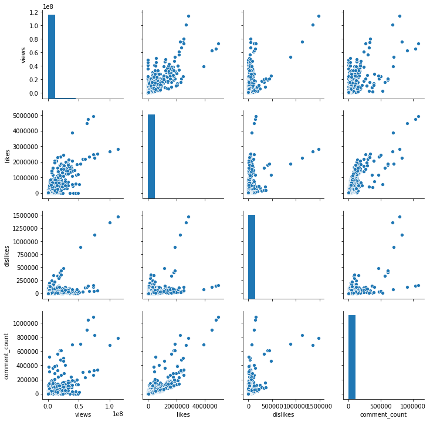

```python
de_num = de[['views','likes','dislikes','comment_count']].copy()
sns.pairplot(de_num)
```

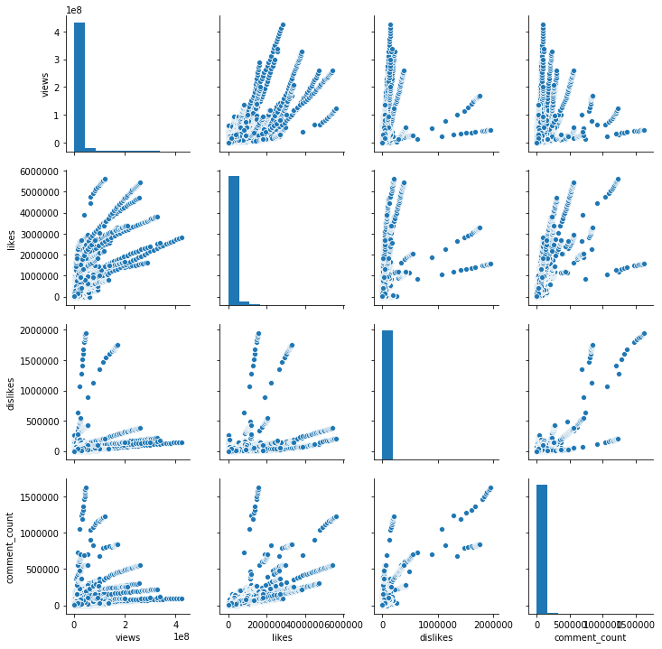

```python
fr_num = gb[['views','likes','dislikes','comment_count']].copy()
sns.pairplot(fr_num)
```

### Q2. For 10 Points: Create a heatmap of correlations between the variables for a region of your choice

> A [heat map (or heatmap)](https://en.wikipedia.org/wiki/Heat_map) is a graphical representation of data where the individual values contained in a matrix are represented as colors.

Seaborn makes it easy to create a heatmap with [`seaborn.heatmap()`](https://seaborn.pydata.org/generated/seaborn.heatmap.html)

- Create a correlation matrix for your numeric variables using Pandas with [`DataFrame.corr()`](https://pandas.pydata.org/pandas-docs/stable/generated/pandas.DataFrame.corr.html). That is, if your dataframe is called `df`, use `df.corr()`.
- Pass in your correlation matrix to `seaborn.heatmap()`, and annotate it with the parameter `annot=True`.
- Are there any interesting correlations? What are they?

```python
# put your code here
us_num.corr()
```

|  | views | likes | dislikes | comment_count |
| --- | --- | --- | --- | --- |
| views | 1.000000 | 0.849177 | 0.472213 | 0.617621 |
| likes | 0.849177 | 1.000000 | 0.447186 | 0.803057 |
| dislikes | 0.472213 | 0.447186 | 1.000000 | 0.700184 |
| comment_count | 0.617621 | 0.803057 | 0.700184 | 1.000000 |

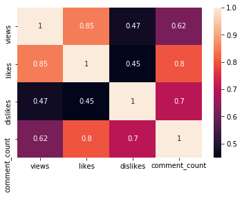

```python
sns.heatmap(us_num.corr(), annot = True)
```

There are interesting correlations. The likes and views are highly correlated (0.85), the likes~comment count also has good correlation along with dislikes ~ comment count.

### Q3. For 15 points: Create and compare OLS models using variables of your choice, for a region of your choice

- select two variables (remember to filter for the region of your choice)
- use the JointGrid approach from our in-class session to visualize the relationship between the variables
- use `statsmodels` to create a regression model
- explain the how the results of the regression analysis help you understand the plot (and vice versa)

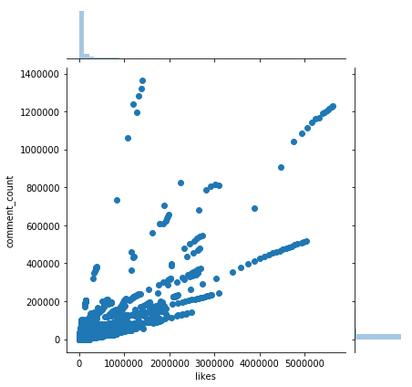

```python
sns.jointplot(x = 'likes', y = 'comment_count', data = us)
```

```python
import statsmodels.api as sm
import statsmodels.formula.api as smf
model1 = smf.ols('comment_count ~ likes', data = us).fit()
model1.summary()
```

OLS Regression Results

| Dep. Variable: | comment_count | R-squared: | 0.645 |
| --- | --- | --- | --- |
| Model: | OLS | Adj. R-squared: | 0.645 |
| Method: | Least Squares | F-statistic: | 7.436e+04 |
| Date: | Sun, 24 Feb 2019 | Prob (F-statistic): | 0.00 |
| Time: | 12:57:43 | Log-Likelihood: | -4.6811e+05 |
| No. Observations: | 40949 | AIC: | 9.362e+05 |
| Df Residuals: | 40947 | BIC: | 9.362e+05 |
| Df Model: | 1 |  |  |
| Covariance Type: | nonrobust |  |  |

|  | coef | std err | t | P>\|t\| | [0.025 | 0.975] |
| --- | --- | --- | --- | --- | --- | --- |
| Intercept | -1306.4145 | 115.883 | -11.274 | 0.000 | -1533.549 | -1079.280 |
| likes | 0.1313 | 0.000 | 272.698 | 0.000 | 0.130 | 0.132 |

| Omnibus: | 95252.426 | Durbin-Watson: | 1.980 |
| --- | --- | --- | --- |
| Prob(Omnibus): | 0.000 | Jarque-Bera (JB): | 1545833159.121 |
| Skew: | 22.790 | Prob(JB): | 0.00 |
| Kurtosis: | 953.751 | Cond. No. | 2.53e+05 |

Warnings:  
[1] Standard Errors assume that the covariance matrix of the errors is correctly specified.  
[2] The condition number is large, 2.53e+05. This might indicate that there are  
strong multicollinearity or other numerical problems.

- I selected likes (independent variable) and comment count (dependent variable).
- From the OLS regression results, the slope is 0.1313 which is positive, which matches the plot where it's easy to tell a positive relationship. Vice versa, the histograms in joinplot are highly skewed, which helps in understanding skew index (skew: 22.790) in regression analysis.

## Part 2: Answer the questions below based on the *[Pokémon dataset](https://www.kaggle.com/abcsds/pokemon)*

- Write Python code that can answer the following questions, and
- Explain your answers in plain English.

### Q4. For 10 Points: Plot the pairs of different ability points (HP, Attack, Sp. Attack, Defense, etc.).

- Which pairs have the most/least correlation coefficients?

```python
pok = pd.read_csv('Pokemon.csv')
pok.columns
```

```
Index(['#', 'Name', 'Type 1', 'Type 2', 'Total', 'HP', 'Attack', 'Defense',
       'Sp. Atk', 'Sp. Def', 'Speed', 'Generation', 'Legendary'],
      dtype='object')
```

```python
pok_ability = pok[['Type 1','HP','Attack','Defense',\
    'Sp. Atk','Sp. Def','Speed']].copy()
pok_ability.head()
```

|  | Type 1 | HP | Attack | Defense | Sp. Atk | Sp. Def | Speed |
| --- | --- | --- | --- | --- | --- | --- | --- |
| 0 | Grass | 45 | 49 | 49 | 65 | 65 | 45 |
| 1 | Grass | 60 | 62 | 63 | 80 | 80 | 60 |
| 2 | Grass | 80 | 82 | 83 | 100 | 100 | 80 |
| 3 | Grass | 80 | 100 | 123 | 122 | 120 | 80 |
| 4 | Fire | 39 | 52 | 43 | 60 | 50 | 65 |

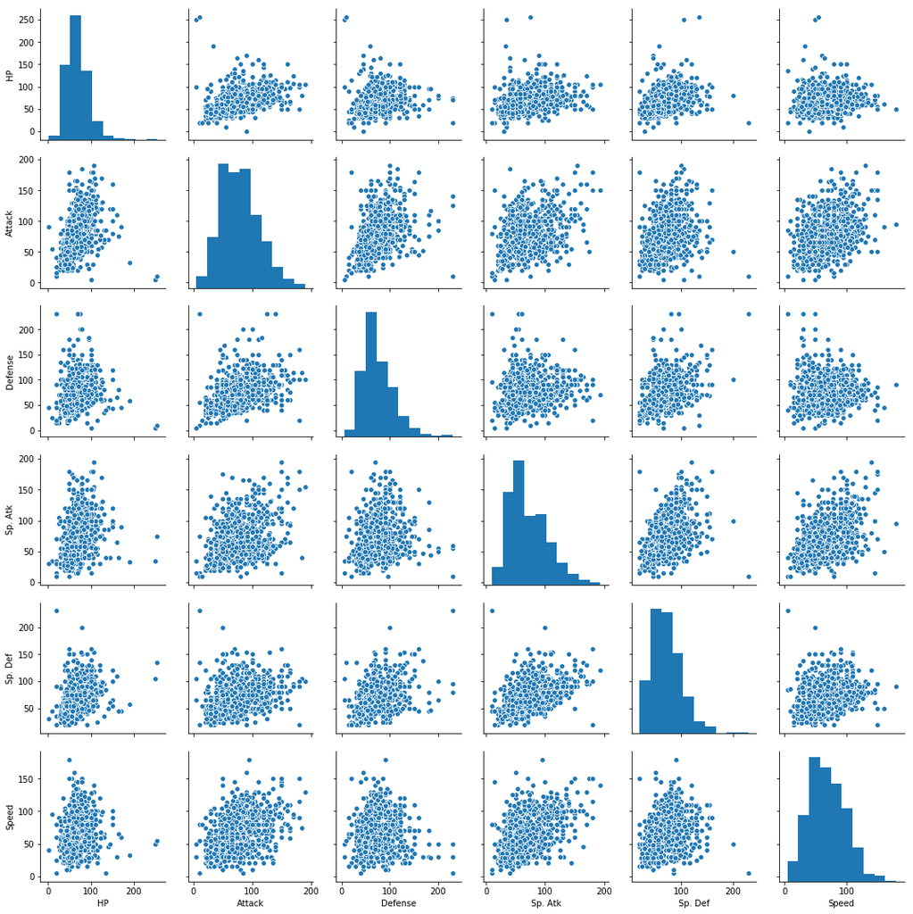

```python
sns.pairplot(pok_ability)
```

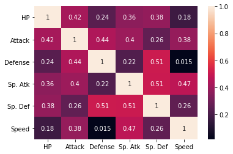

```python
sns.heatmap(pok_ability.corr(), annot = True)
```

From the heatmap, the Sp.Atk ~ Sp.Def pair and Defense ~ Sp.Def pair have the most correlation coefficient (0.51). The Defense ~ Speed pair has the least correlation coefficient (0.015)

### Q5. For 15 Points: Plot the distribution of ability points per Pokémon type

- How would you describe each Pokémon type with different ability points?

```python
pok['Type 1'].value_counts()
```

```
Water       112
Normal       98
Grass        70
Bug          69
Psychic      57
Fire         52
Electric     44
Rock         44
Ghost        32
Ground       32
Dragon       32
Dark         31
Poison       28
Steel        27
Fighting     27
Ice          24
Fairy        17
Flying        4
Name: Type 1, dtype: int64
```

```python
pok_ability.head()
```

|  | Type 1 | HP | Attack | Defense | Sp. Atk | Sp. Def | Speed |
| --- | --- | --- | --- | --- | --- | --- | --- |
| 0 | Grass | 45 | 49 | 49 | 65 | 65 | 45 |
| 1 | Grass | 60 | 62 | 63 | 80 | 80 | 60 |
| 2 | Grass | 80 | 82 | 83 | 100 | 100 | 80 |
| 3 | Grass | 80 | 100 | 123 | 122 | 120 | 80 |
| 4 | Fire | 39 | 52 | 43 | 60 | 50 | 65 |

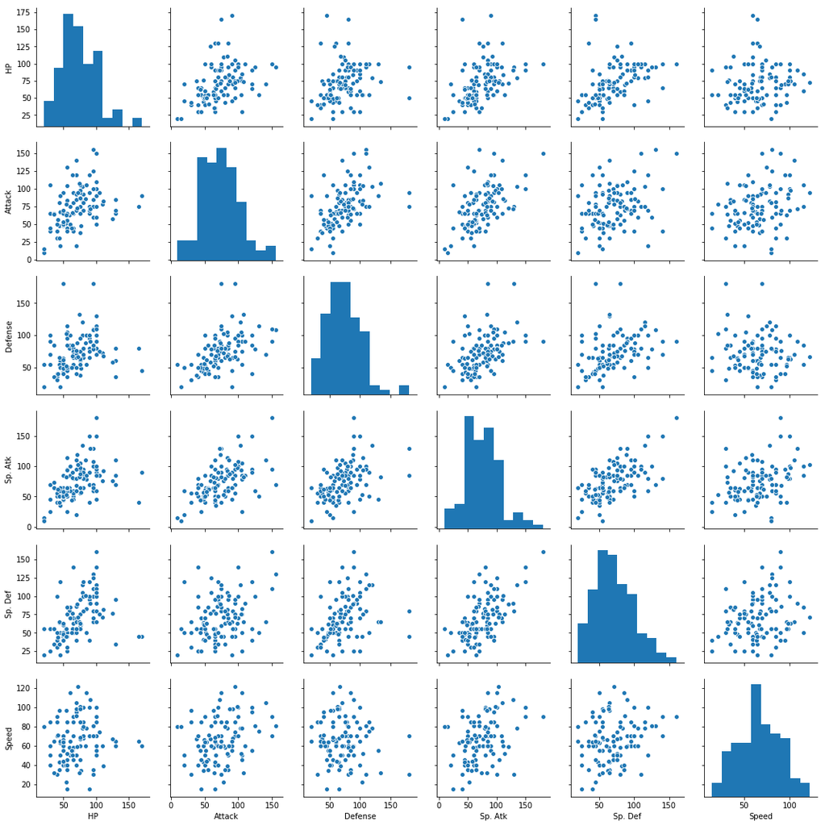

```python
sns.pairplot(pok_ability[pok_ability['Type 1'] == 'Water'])
```

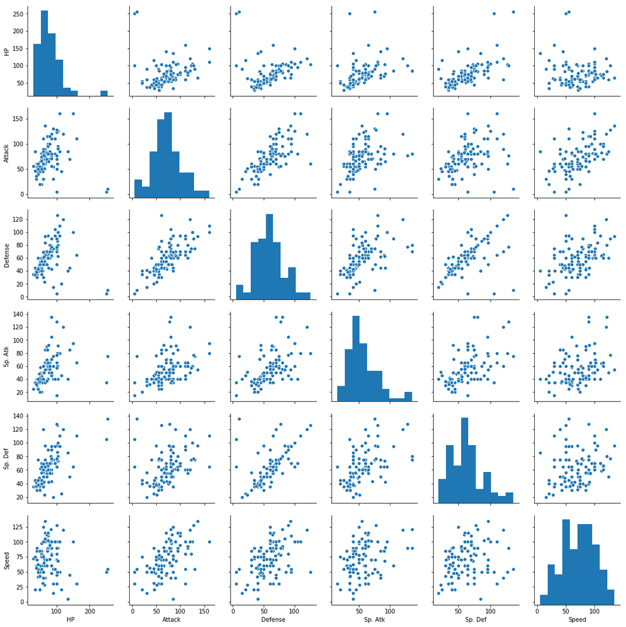

```python
sns.pairplot(pok_ability[pok_ability['Type 1'] == 'Normal'])
```

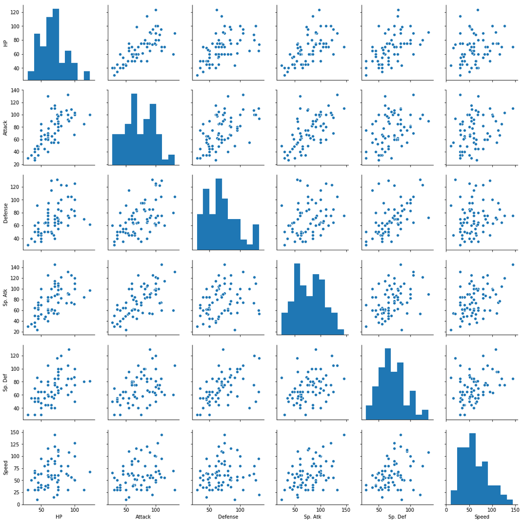

```python
sns.pairplot(pok_ability[pok_ability['Type 1'] == 'Grass'])
```

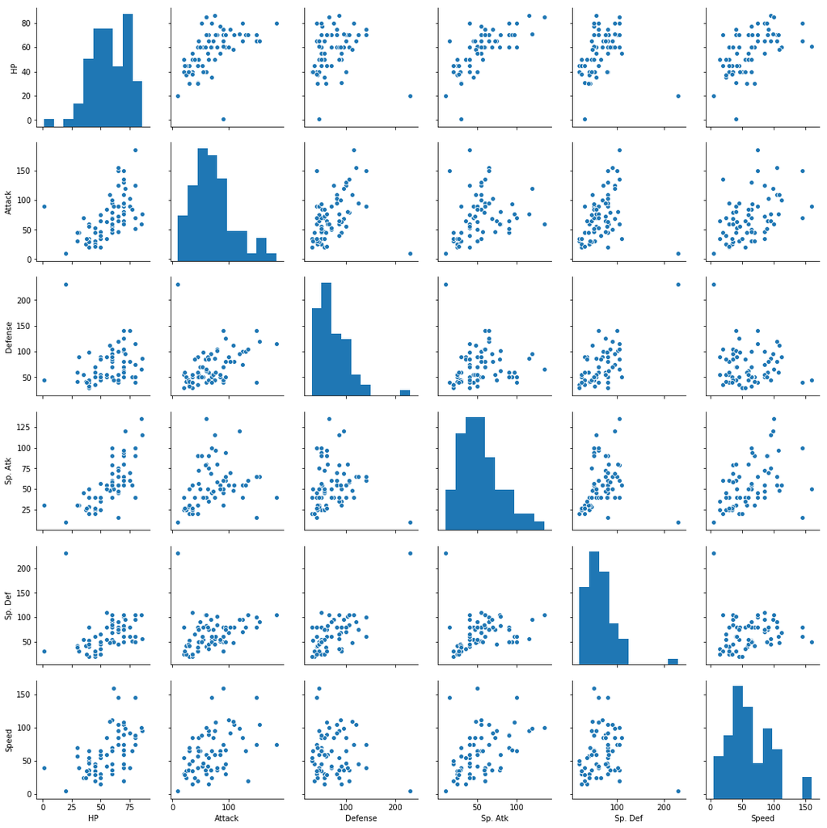

```python
sns.pairplot(pok_ability[pok_ability['Type 1'] == 'Bug'])
```

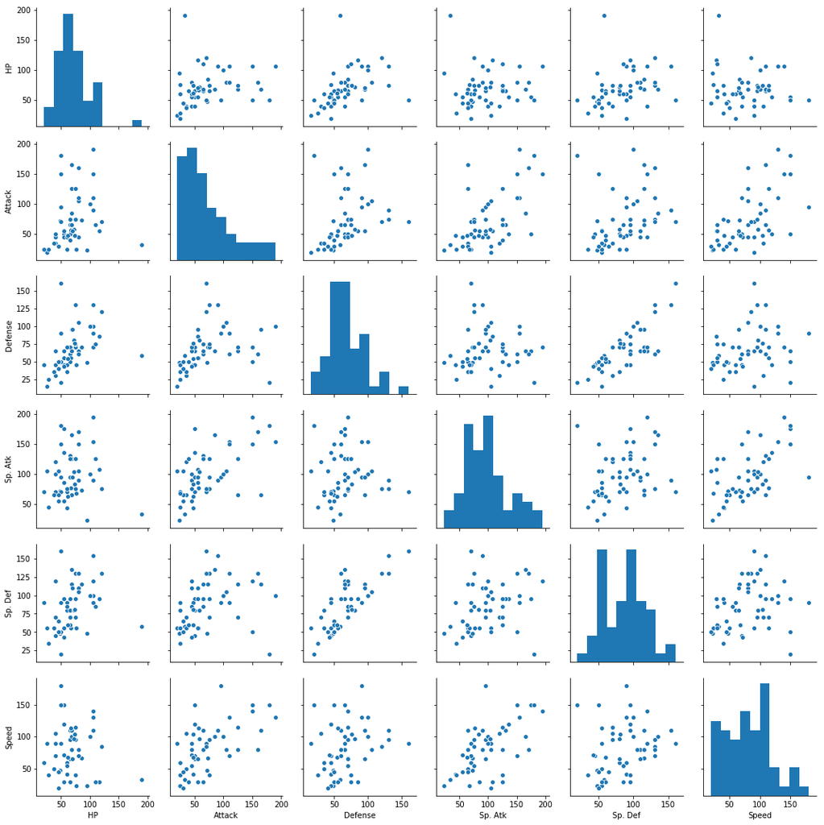

```python
sns.pairplot(pok_ability[pok_ability['Type 1'] == 'Psychic'])
```

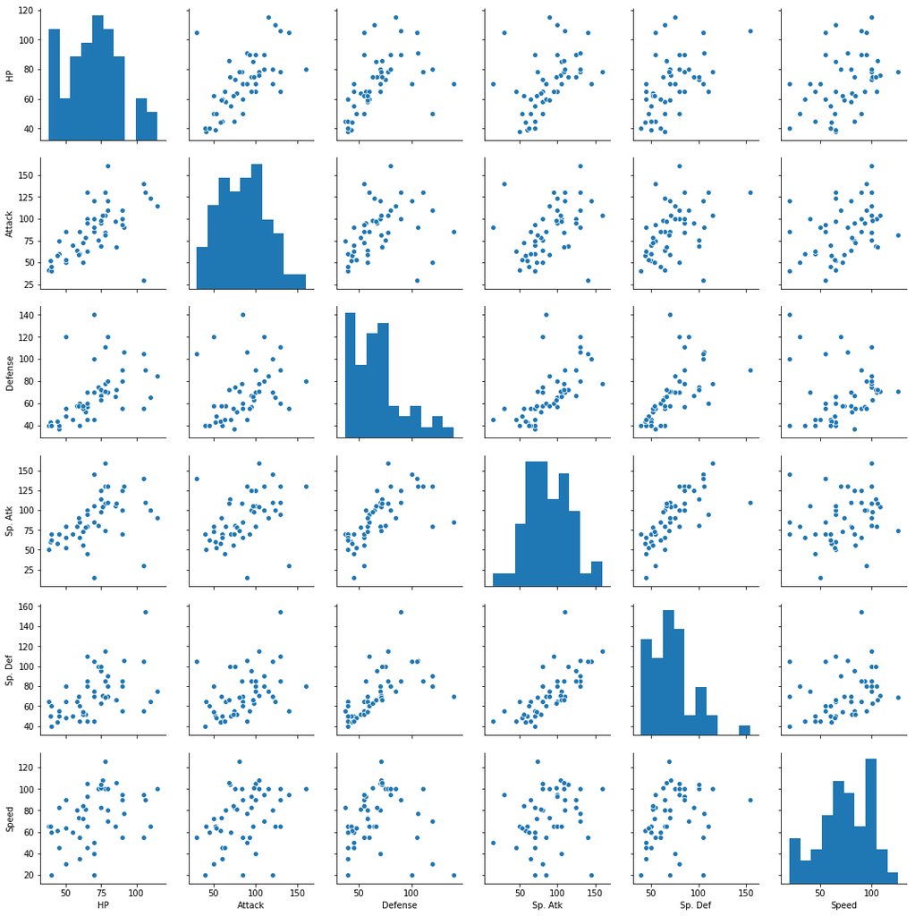

```python
sns.pairplot(pok_ability[pok_ability['Type 1'] == 'Fire'])
```

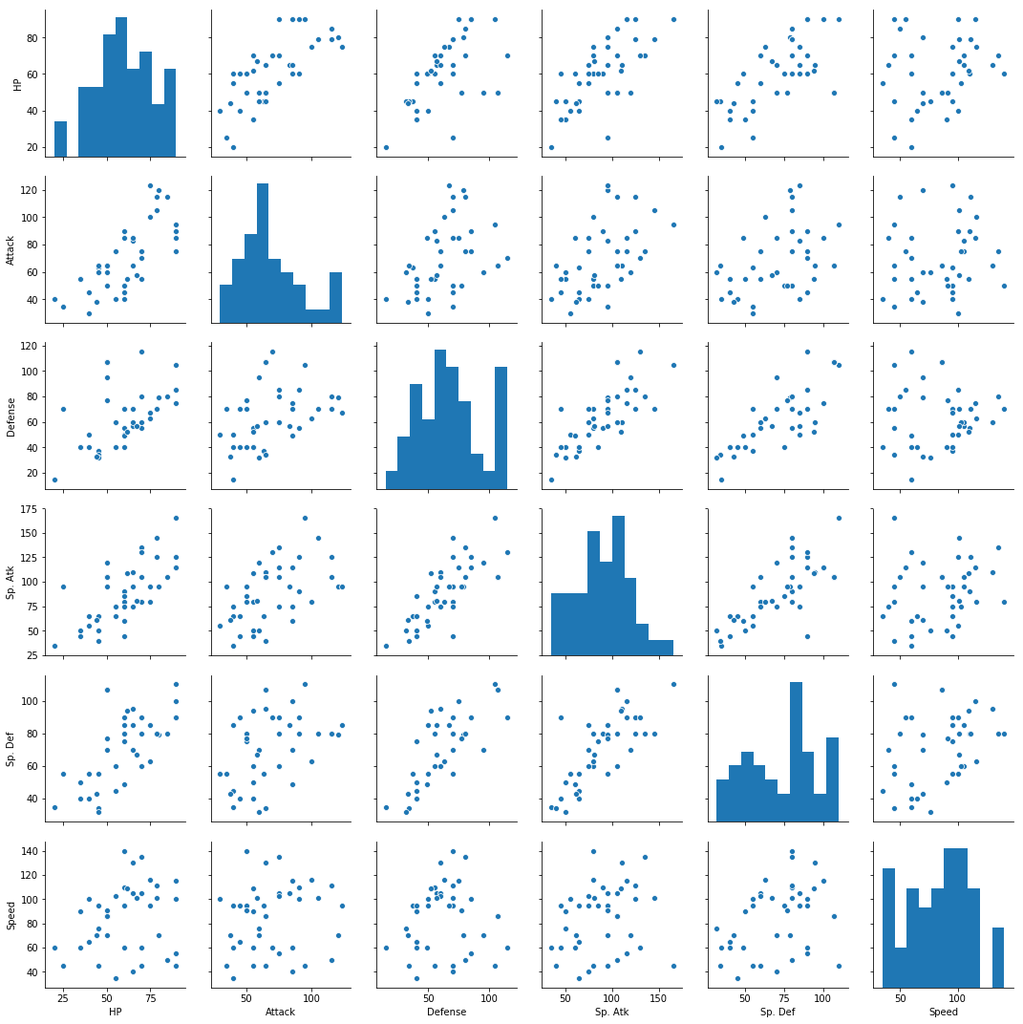

```python
sns.pairplot(pok_ability[pok_ability['Type 1'] == 'Electric'])
```

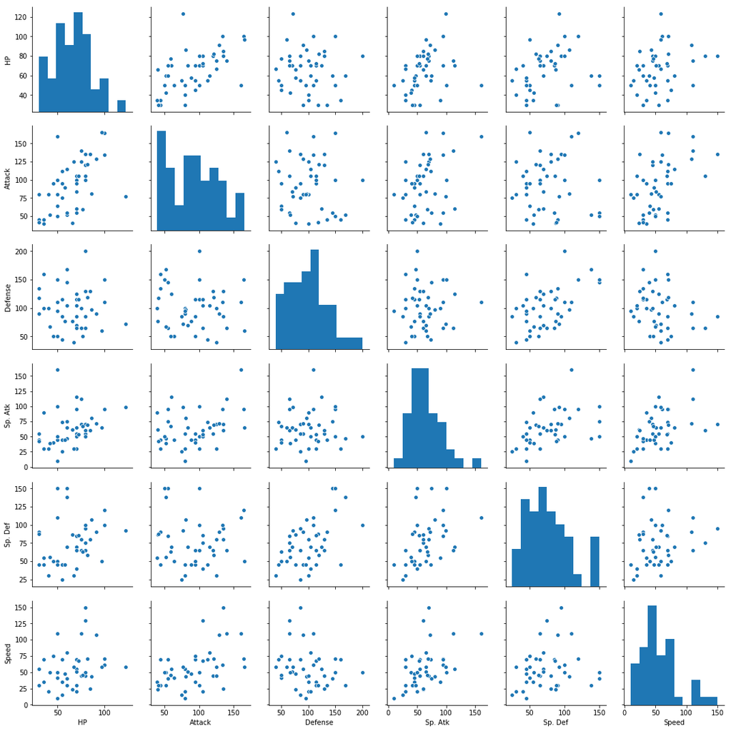

```python
sns.pairplot(pok_ability[pok_ability['Type 1'] == 'Rock'])
```

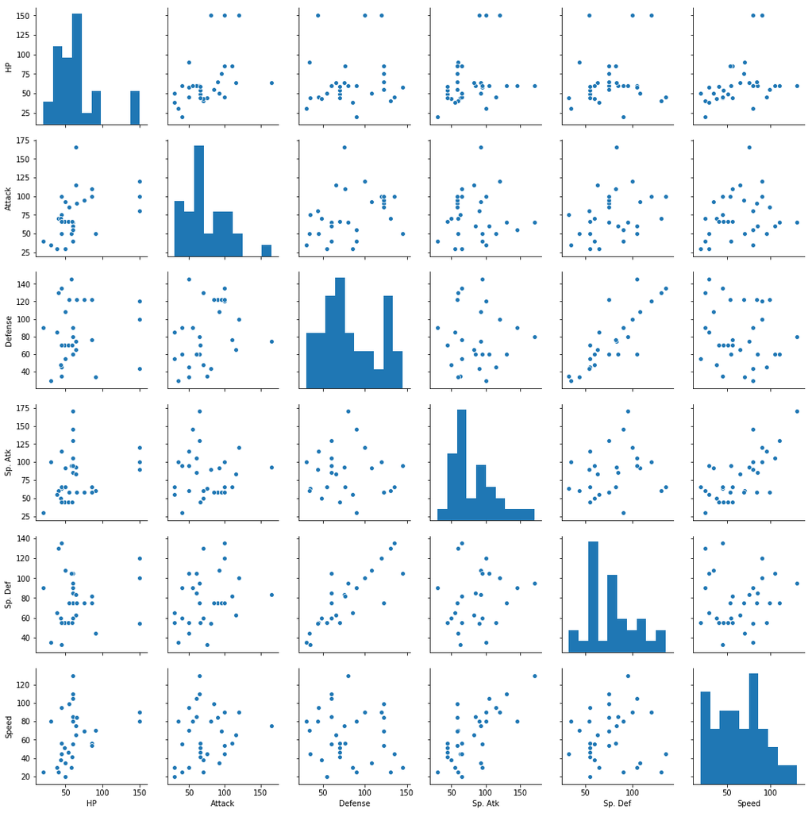

```python
sns.pairplot(pok_ability[pok_ability['Type 1'] == 'Ghost'])
```

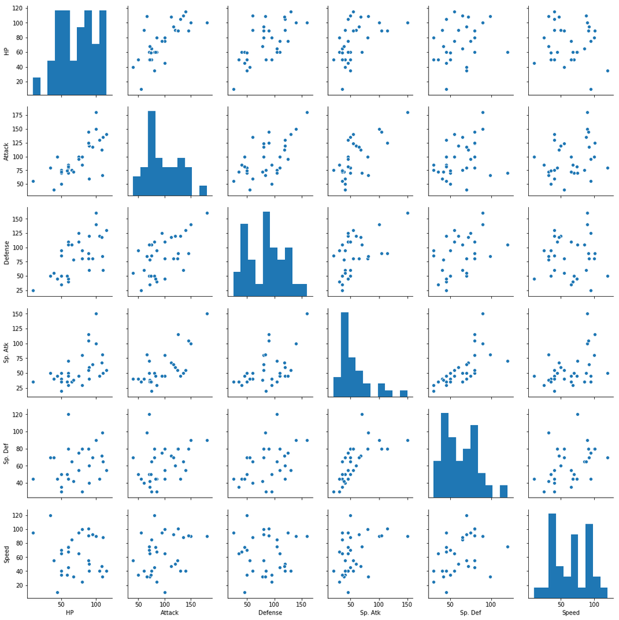

```python
sns.pairplot(pok_ability[pok_ability['Type 1'] == 'Ground'])
```

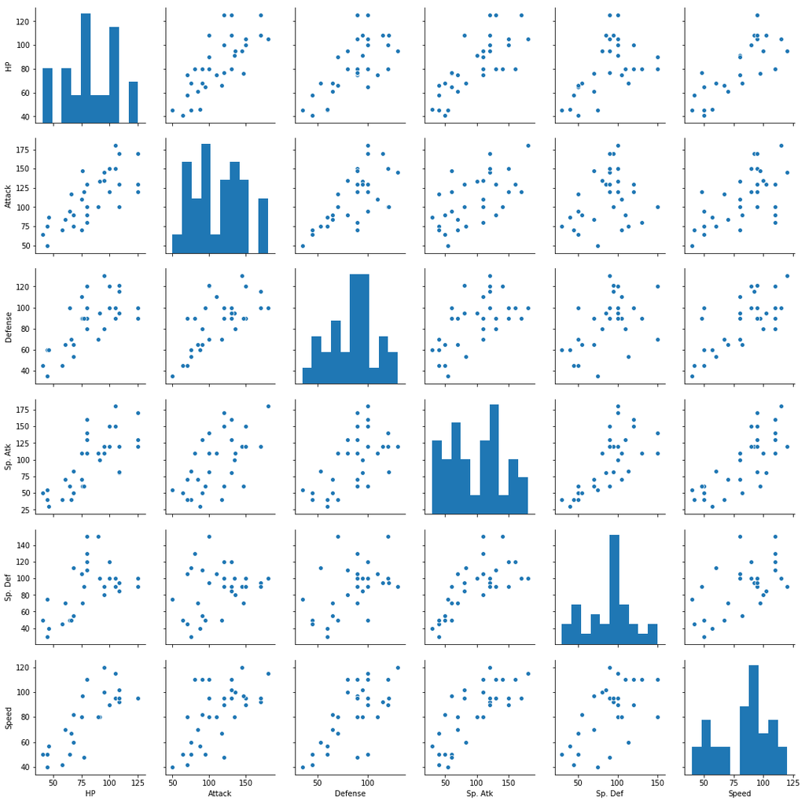

```python
sns.pairplot(pok_ability[pok_ability['Type 1'] == 'Dragon'])
```

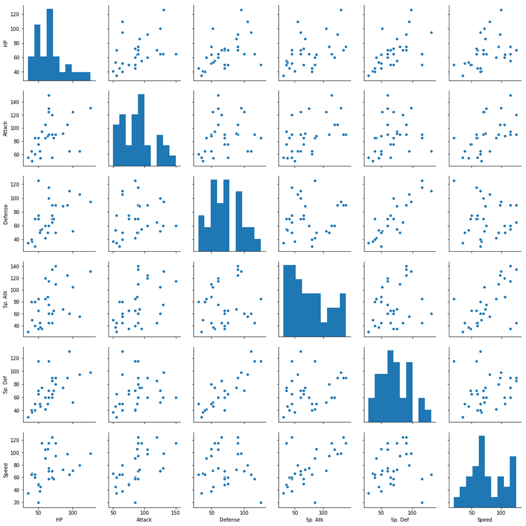

```python
sns.pairplot(pok_ability[pok_ability['Type 1'] == 'Dark'])
```

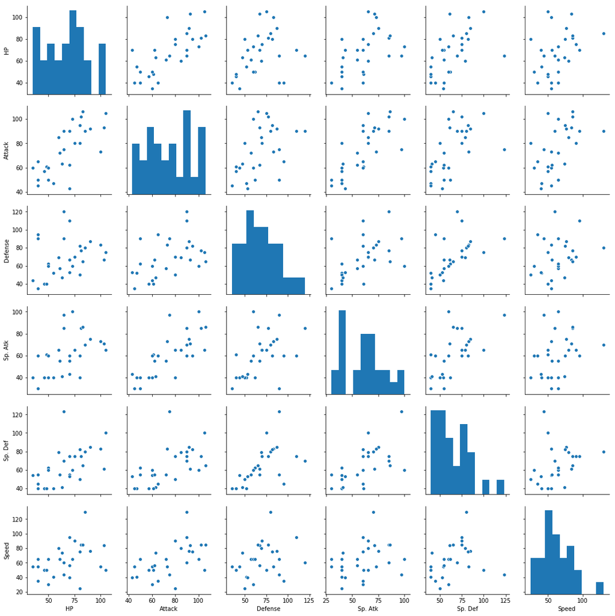

```python
sns.pairplot(pok_ability[pok_ability['Type 1'] == 'Poison'])
```

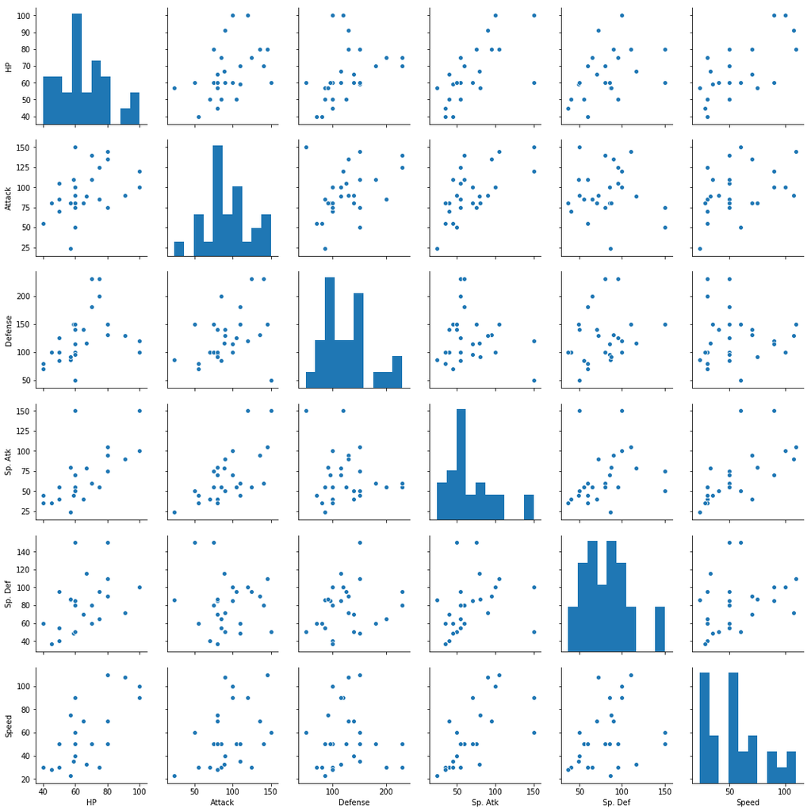

```python
sns.pairplot(pok_ability[pok_ability['Type 1'] == 'Steel'])
```

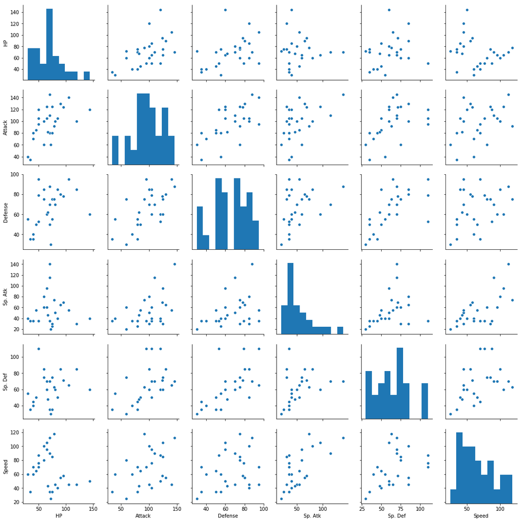

```python
sns.pairplot(pok_ability[pok_ability['Type 1'] == 'Fighting'])
```